# Activity E

APCV 302 2023 FA 7W1

Author

Affiliation

[Jared Parker](https://arizona.digication.com/eportfolio-for-j-parker)

[Student at University of Arizona](https://azcast.arizona.edu)

Published

October 7, 2023

# USA Energy Use

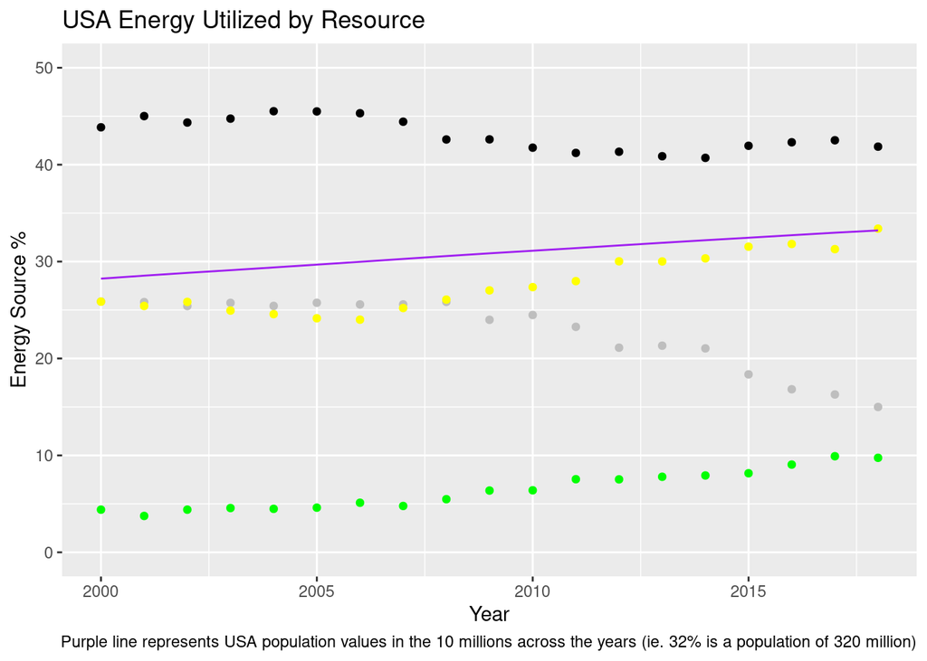

**LEGEND**

GREY = Coal

BLACK = Oil

YELLOW = Natural Gas

GREEN = Renewable Resources

PURPLE LINE = Population in 10 Millions

*Note: The above color assignments will be used for the graphs below*

| Pearson Correlation Coefficient Analysis of US Population on Electricity Generated estimate | Pearson Correlation Coefficient Analysis of US Population on Electricity Generated statistic | Pearson Correlation Coefficient Analysis of US Population on Electricity Generated p.value | Pearson Correlation Coefficient Analysis of US Population on Electricity Generated parameter | Pearson Correlation Coefficient Analysis of US Population on Electricity Generated conf.low | Pearson Correlation Coefficient Analysis of US Population on Electricity Generated conf.high | Pearson Correlation Coefficient Analysis of US Population on Electricity Generated method | Pearson Correlation Coefficient Analysis of US Population on Electricity Generated alternative |
| --- | --- | --- | --- | --- | --- | --- | --- |
| 0.7808181 | 5.153025 | 7.97e-05 | 17 | 0.5060995 | 0.9116916 | Pearson's product-moment correlation | two.sided |

The above information was generated using a Pearson correlation coefficient analysis. The p-value of $7.9656543\times 10^{-5}$ is the probability that these results occurred by chance, meaning the values used to draw the conclusions in this document are accurate *and* significant.

We can see the overall usage in the United States of different resources, coal, oil, natural gas, and renewable sources, as a percentage of the total energy consumed for each year from 2000 to 2018 in the above scatterplot. To add a frame of reference, the purple line is the U.S. population in the 10 millions at that point in time. In order to determine if there was a relationship between population size and the overall *electricity* generated for the U.S. a Pearson correlation coefficient analysis was performed. A **strong** positive relationship was found with a correlation coefficient of 0.7808181 which denotes that the electricity generated *was* dependent upon the population over the years, and as the population grew, so did the electricity generated. We can further dive into the specifics of each resource’s dependency on population throughout the years to predict which resource should be invested in. Below are graphs that break down the usage of each resource in a histogram style with the population line included as a reference along with a table containing the related data.

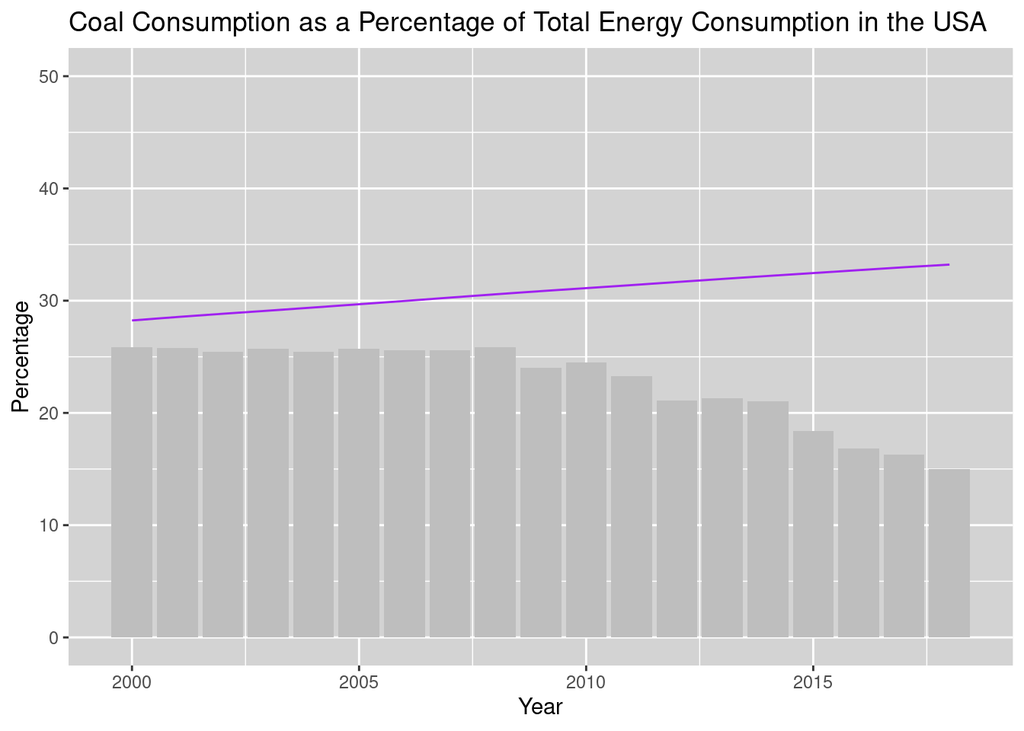

Correlation Coefficient is -0.8985907 showing a **strong** negative relationship.

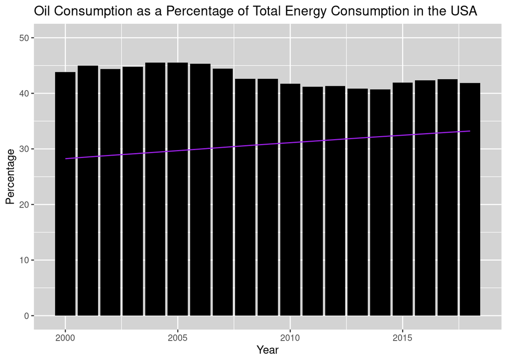

Correlation Coefficient is -0.6853243 showing a **moderate** negative relationship.

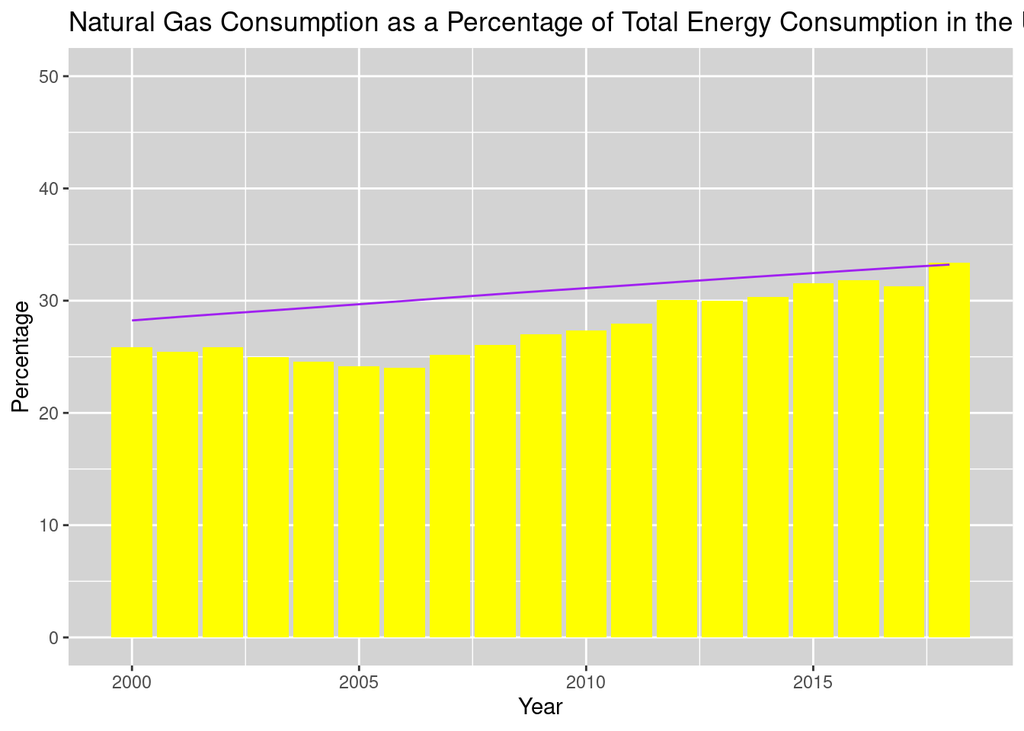

Correlation Coefficient is 0.8813689 showing a **strong** positive relationship.

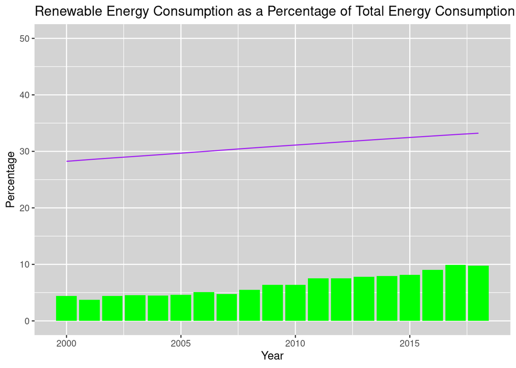

Correlation Coefficient is 0.9659428 showing a **very strong** positive relationship.

| Country | Year | Coal Consumption % | Oil Consumption % | Natural Gas Consumption % | Renewable Consumption % |
| --- | --- | --- | --- | --- | --- |
| United States | 2000 | 25.87727 | 43.85562 | 25.86645 | 4.400651 |
| United States | 2001 | 25.81877 | 45.01167 | 25.41788 | 3.751683 |
| United States | 2002 | 25.41237 | 44.34714 | 25.84015 | 4.400339 |
| United States | 2003 | 25.74073 | 44.74905 | 24.94282 | 4.567399 |
| United States | 2004 | 25.42435 | 45.51547 | 24.57603 | 4.484152 |
| United States | 2005 | 25.75001 | 45.49623 | 24.14736 | 4.606395 |
| United States | 2006 | 25.57620 | 45.30659 | 24.00511 | 5.112095 |
| United States | 2007 | 25.58047 | 44.43270 | 25.20703 | 4.779800 |
| United States | 2008 | 25.84492 | 42.59914 | 26.07653 | 5.479411 |
| United States | 2009 | 23.99077 | 42.60999 | 27.02728 | 6.371961 |
| United States | 2010 | 24.48577 | 41.75375 | 27.36213 | 6.398349 |
| United States | 2011 | 23.26576 | 41.21109 | 27.98022 | 7.542927 |
| United States | 2012 | 21.11264 | 41.33415 | 30.02661 | 7.526607 |
| United States | 2013 | 21.32090 | 40.87156 | 30.01503 | 7.792516 |
| United States | 2014 | 21.04093 | 40.70269 | 30.32821 | 7.928166 |
| United States | 2015 | 18.36022 | 41.94791 | 31.53624 | 8.155626 |
| United States | 2016 | 16.82237 | 42.30958 | 31.81631 | 9.051735 |
| United States | 2017 | 16.28646 | 42.51826 | 31.28245 | 9.912824 |
| United States | 2018 | 14.99440 | 41.85933 | 33.39547 | 9.750798 |

As we compare the above graphs and associated data, relationships between the population size and the use of specific resources over time are clear: the demand for natural gas and renewable sources grows with the population while the demand for coal and oil will decline with population growth. Investing in renewable sources of power generation may seem wise at this junction, and predictions for future growth would support those investments, but there is an important factor to analyze before that will happen.

# Do Resources Impact Other Resources?

If one resource’s utilization is impacted by the use of another than the predictions we will make need to factor that in, otherwise the investments cannot be made with certainty. The method by which we analyze the potential relationships will be an ANOVA test, which will compare the variability between our resources, accounting for the potential hidden interactions between the groups. Our ANOVA test, as can be seen below and is detailed on the side, revealed that the variability in our population data probably does not have a significant impact on our data and it could be due to randomness, especially when all values are taken into context. The unfortunate discovery from our test is the certainty with which we can say the resource consumption sources **definitely** has an impact on one another and any predictions we made are likely to be false due to high variability and interaction between the resources. While we would **love** to urge investment in “green” energy sources due to our data, it is far more likely that the growth in renewable sources is also being affected by additional, unaccounted for variables. One probable cause could be the relatively recent push for more renewable sources being used to combat climate-change/global warming.

Woah! Those are *some* **extreme** numbers. Here’s some insight behind them:

- The values in the **Sum Sq** column illustrates how much variability is caused by the population, by the different resources, the interaction between those two categories, and the unexplained variability (from top to bottom) Higher values like those we see indicates the strength of impact.
- The first two values in the **Statistics** column illustrates how significant the differences are between the population values and the different resources utilization values (respectively). The next value quantitatively ascertains the significance of the interaction between population and resource use.
- The **p.value** column represents how likely the the values obtained were by chance. A **p-value** that is *less than* .05 is represents an **unlikely** probability that it was due to randomness and is **likely** significant, where a **p-value** that is *less than* .001 represents a **high** significance with it being **extremely unlikely** to be due to chance.

| ANOVA Test on Relationship Between Each Resource and US Population term | ANOVA Test on Relationship Between Each Resource and US Population df | ANOVA Test on Relationship Between Each Resource and US Population sumsq | ANOVA Test on Relationship Between Each Resource and US Population meansq | ANOVA Test on Relationship Between Each Resource and US Population statistic | ANOVA Test on Relationship Between Each Resource and US Population p.value |
| --- | --- | --- | --- | --- | --- |
| population | 1 | 172945.7 | 172945.7 | 1.423148 | 2.370318e-01 |
| source | 3 | 744815326.7 | 248271775.6 | 2042.996857 | 1.555126e-66 |
| population:source | 3 | 25141408.1 | 8380469.4 | 68.961816 | 1.372132e-20 |
| Residuals | 68 | 8263586.3 | 121523.3 | NA | NA |